# R Notebook

1. What geom would you use to draw a line chart? A boxplot? A histogram? An area chart?

line chart - geom_line box plot - geom_box plot histogram - geom_histogram area chart - geom area

2. Run this code in your head and predict what the output will look like. Then, run the code in R and check your predictions.

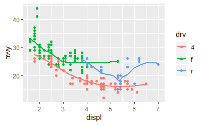

```r
ggplot(data = mpg, mapping = aes(x = displ, y = hwy, color = drv)) + geom_point() + geom_smooth(se = FALSE)
```

What does show.legend = FALSE do? What happens if you remove it? Why do you think I used it earlier in the chapter?

show.legend = False, removes the legend from the graph

4. What does the se argument to geom_smooth() do?

The se arguement of geom_smooth if set to false, does not show the deviation of the data.

5. Will these two graphs look different? Why/why not?

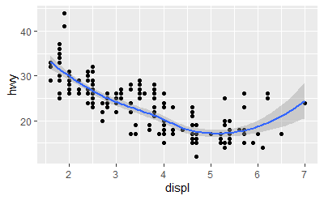

```r
ggplot(data = mpg, mapping = aes(x = displ, y = hwy)) + geom_point() + geom_smooth()
```

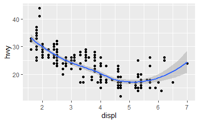

```r
ggplot() + geom_point(data = mpg, aes(x = displ, y = hwy)) + geom_smooth(data = mpg, aes(x = displ, y = hwy))
```

Recreate the R code necessary to generate the following graphs.

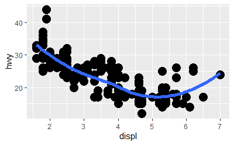

```r
ggplot(data = mpg, aes(x = displ, y = hwy)) + geom_point(size = 5) + geom_smooth(size = 2, se = FALSE)
```

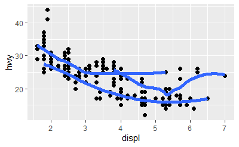

```r
ggplot(data = mpg) + geom_point(mapping = aes(x = displ, y = hwy), size = 2) + geom_smooth(mapping = aes(x = displ, y = hwy, group = drv), size = 2, , se = FALSE)
```

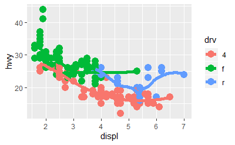

```r
ggplot(data = mpg) + geom_point(mapping = aes(x = displ, y = hwy, colour = drv), size = 4) + geom_smooth(mapping = aes(x = displ, y = hwy, group = drv, colour = drv), size = 2, se = FALSE)
```

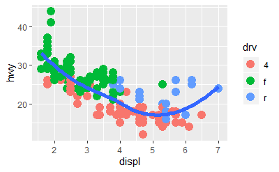

```r
ggplot(data = mpg) + geom_point(mapping = aes(x = displ, y = hwy, color = drv), size = 4) + geom_smooth(mapping = aes(x= displ, y = hwy), size = 2, se = FALSE)
```

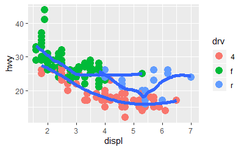

```r
ggplot(data = mpg) + geom_point(mapping = aes(x = displ, y = hwy, color = drv), size = 4) + geom_smooth(mapping = aes(x = displ, y = hwy, group = drv), size  = 2, se = FALSE)
```

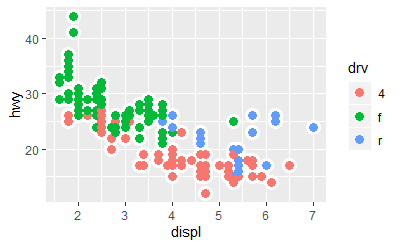

```r
ggplot(data = mpg) + geom_point(mapping = aes(x = displ, y = hwy), color = "white", size = 5) + geom_point(mapping = aes(x= displ, y = hwy, color = drv),size = 3)
```

Exercises - 3.8.1

1. What is the problem with this plot? How could you improve it?

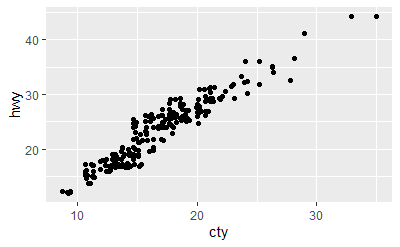

```r
ggplot(data = mpg, mapping = aes(x = cty, y = hwy)) + geom_point(position = "jitter")
```

the entire data have not been shown, many of the data points, have been clubbed together

2. What parameters to geom_jitter() control the amount of jittering?